# ChainLadder Package Projections in Action

Andy Merlino

2015-03-18

[source code](https://raw.githubusercontent.com/merlinoa/ractuary-studies/master/chainladder-review.Rmd)

This analysis aims to measure the accuracy of the `ChainLadder::MackChainLadder()` and `ChainLadder::BootChainLadder()` reserve projection functions by comparing the projected reserves to actual reserves.

### Background

An insurance reserve is the insurer’s liability for future payments. The correct value of a reserve, at any given time, is equal to the ultimate loss (loss amount after all claims have been paid out) less the amount that has already been paid.

The [ChainLadder](http://cran.r-project.org/web/packages/ChainLadder/vignettes/ChainLadder.pdf) package by Markus Gesmann, Dan Murphy, and Wayne Zhang includes functions for estimating reserves. `MackChainLadder()` provides a distribution free calculation of the standard error of the reserve projection. `BootChainLadder()` uses two stage bootstrap/simulation technique to determine the standard error of the reserve projection.

### Data

The CAS website provides historical U.S. insurance loss data across 6 different lines of business and many different companies. Data from accident years 1988 through 1997 evaluated at each year end (i.e. the upper left triangle of losses) is used to run the `ChainLadder` functions. In addition to the upper left triangle, the CAS data set includes actual losses for each accident year developed for 10 years; thus we can compare the projected reserve to the actual reserve after 10 development years.

For more information on the data see the [CAS webpage](http://www.casact.org/research/index.cfm?fa=loss_reserves_data).

The following table breaks down the number of companies included in this analysis by line of business.

| Line of Business | Number of Companies |
| --- | --- |
| Commercial Auto | 41 |
| Medical Malpractice | 7 |
| Other Liabiltiy | 17 |
| Private Passenger | 66 |
| Product Liability | 3 |
| Workers Compensation | 44 |

### Analysis

I run the `MackChainLadder()` and `BootChainLadder()` reserve projection functions on each company. I subtract the projected reserve from the actual reserve to arrive at the projection error. To normalize the projection error, I divide the projection error by the estimated projection standard error. Put a little more formally, I am simply interested in the normalized projection error, $Z$, where:

$Z = \frac{(p - \hat{p})}{\hat{se(\hat{p})}}$

Where:

- $\hat{p}$ is the projected reserve.
- $\hat{se(\hat{p})}$ is the estimated standard error of the projected reserve.
- $p$ is the actual reserve. Where the actual reserve is the paid or incurred amount after 10 development years less the paid or incurred amount at the time of the projection estimate.

The following histograms should provide a visual interpretation of how the reserve projection errors are distributed around the reserve projection.

### Histograms

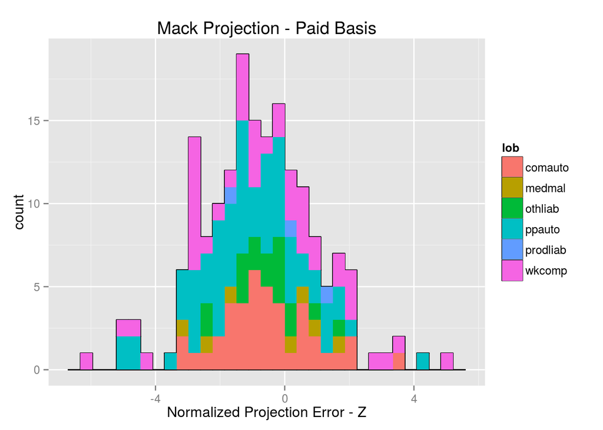

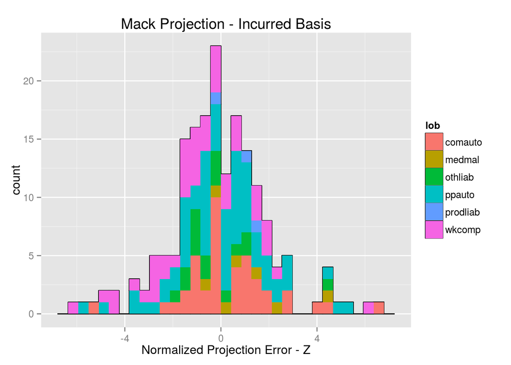

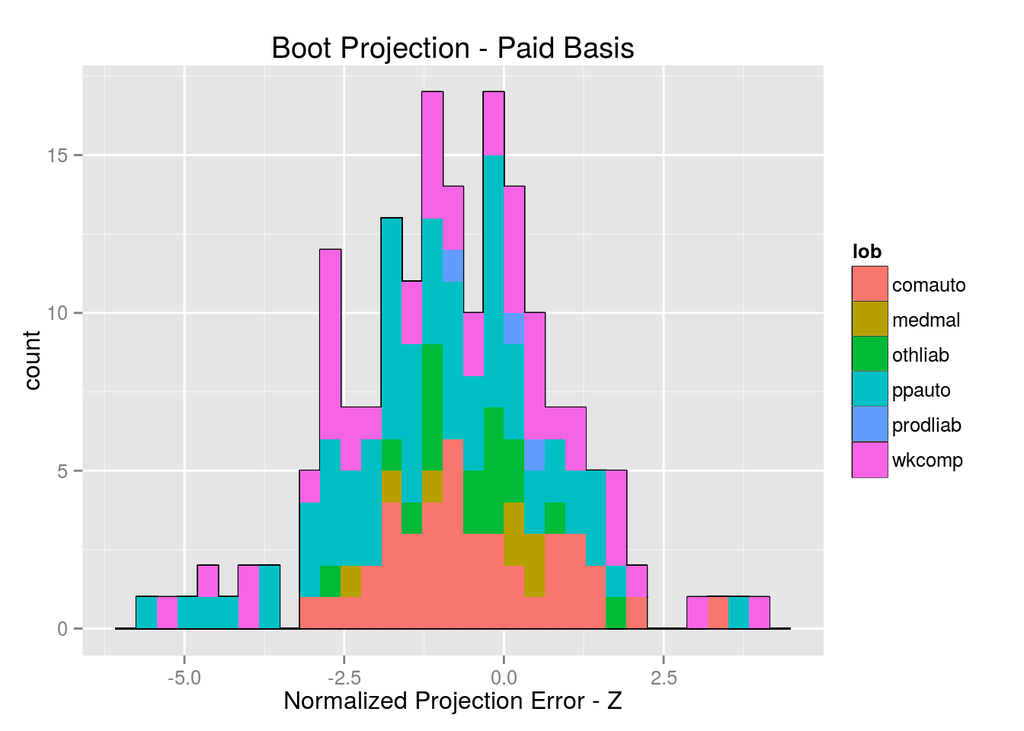

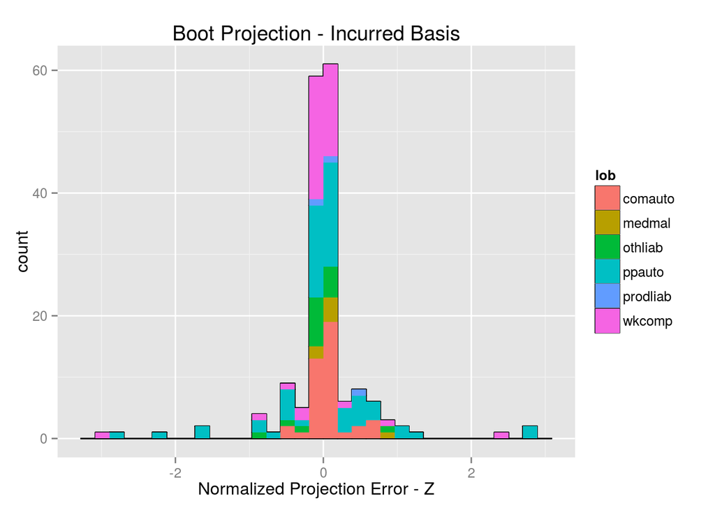

### Initial Take Aways

Both the Mack and Boot paid reserve projections appear to slightly overestimate the actual reserve across all lines of business. Several factors could be responsible for this overestimation (e.g. higher inflation in the years used to estimate the reserve than in the years after 1997).

The incurred normalized projection errors tend to be smaller in absolute value terms than the paid reserve projections.

The `BootChainLadder()` function on incurred losses gave significantly more accurate reserve projections than what would be expected if the projection errors were from the standard normal distribution.